# Visualizing the Indian Panchanga with VedicDateTime

Peeyush

2025-08-04

# Introduction

The **VedicDateTime** package brings the power of the Indian lunisolar calendar (Panchanga) to R, allowing users to calculate and visualize Tithi, Nakshatra, Rashi, Ritu, and more, for any date and location. In this document, we demonstrate how to use these functions for **rich, informative, and beautiful visualizations** using `ggplot2`. All examples use New Delhi, India.

## Panchanga Data Preparation

First, we generate Panchanga data for July 2024 in New Delhi, extracting Tithi, Nakshatra, Rashi, and Ritu for each day. This forms the basis for our visualizations.

```r
dates <- seq.Date(as.Date("2024-07-01"), as.Date("2024-07-31"), by = "1 day")
jd <- gregorian_to_jd(day(dates), month(dates), year(dates))
place <- c(28.6139, 77.2090, 5.5) # New Delhi

# Compute panchanga columns for each day
panchanga <- data.frame(
  date = dates,
  jd = jd,
  tithi = sapply(jd, function(x) get_tithi_name(x, place)),
  nakshatra = sapply(jd, function(x) get_nakshatra_name(x, place)$nakshatra[1]),
  rashi = get_rashi_name(jd),
  ritu = get_ritu_name(month(dates))
)

head(panchanga)
```

```
##         date      jd                                    tithi  nakshatra
## 1 2024-07-01 2460493    Krishna paksha ekadashi till 32:42:49    Bharani
## 2 2024-07-02 2460494    Krishna paksha dvadashi till 31:10:56    Kritika
## 3 2024-07-03 2460495  Krishna paksha trayodashi till 29:54:36     Rohini
## 4 2024-07-04 2460496 Krishna paksha chaturdashi till 28:58:22 Mrigashira
## 5 2024-07-05 2460497                   Amavasya till 28:27:24      Ardra
## 6 2024-07-06 2460498     Shukla paksha prathama till 28:26:37  Punarvasu
##       rashi   ritu
## 1     Mesha Sharad
## 2     Mesha Sharad
## 3 Vrushabha Sharad
## 4 Vrushabha Sharad
## 5   Mithuna Sharad
## 6   Mithuna Sharad
```

## 1. Tithi Calendar Strip

**Purpose:** This plot displays the progression of Tithis (lunar days) across the month, with each tile representing the Tithi for a particular day. This visually encodes the lunar rhythm and the occurrence of special days like Amavasya and Poornima.

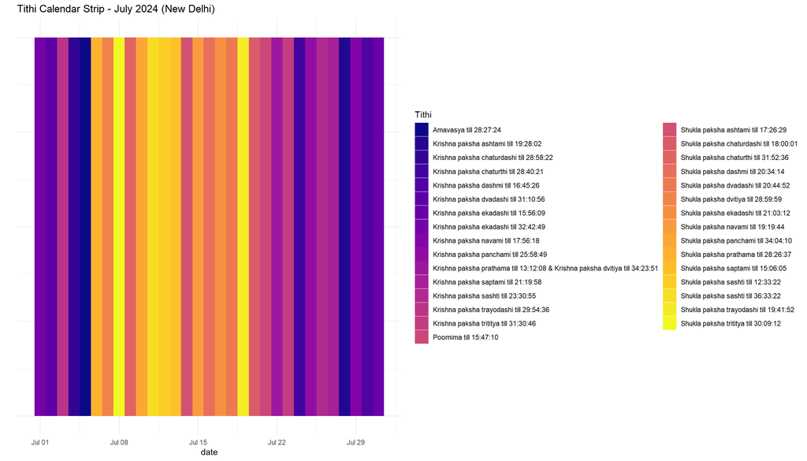

```r
ggplot(panchanga, aes(x = date, y = 1, fill = tithi)) +
  geom_tile() +
  scale_fill_viridis_d(option = "plasma") +
  theme_minimal() +
  labs(
    title = "Tithi Calendar Strip - July 2024 (New Delhi)",
    y = "",
    fill = "Tithi"
  ) +
  theme(axis.text.y = element_blank(), axis.ticks.y = element_blank())
```

## 2. Day Length Through the Year

**Purpose:** This plot shows the variation in day length (sunrise to sunset) across an entire year, illustrating the impact of latitude and season on sunlight duration.

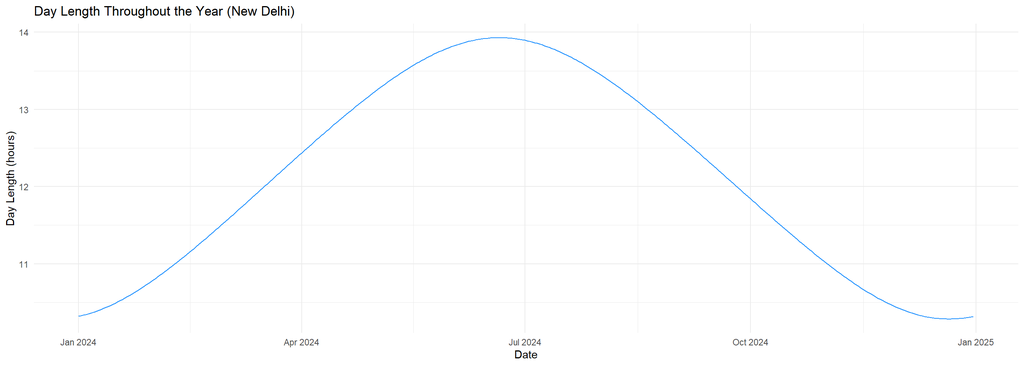

```r
full_year_dates <- seq.Date(as.Date("2024-01-01"), as.Date("2024-12-31"), by = "1 day")
jd_full <- gregorian_to_jd(day(full_year_dates), month(full_year_dates), year(full_year_dates))
place <- c(28.6139, 77.2090, 5.5)

daylen <- sapply(jd_full, function(x) day_duration(x, place)$duration_hours)

ggplot(data.frame(date = full_year_dates, day_length = daylen), aes(x = date, y = day_length)) +
  geom_line(color = "dodgerblue") +
  theme_minimal() +
  labs(
    title = "Day Length Throughout the Year (New Delhi)",
    x = "Date",
    y = "Day Length (hours)"
  )
```

**Interpretation:** Note the longest days around the solstice and shortest days in winter, a hallmark of Earth’s axial tilt.

## 3. Nakshatra Frequency Barplot

**Purpose:** To reveal which Nakshatras are most frequent in the selected month. Nakshatras are 27 divisions of the sky in Indian astronomy, each day aligned with one.

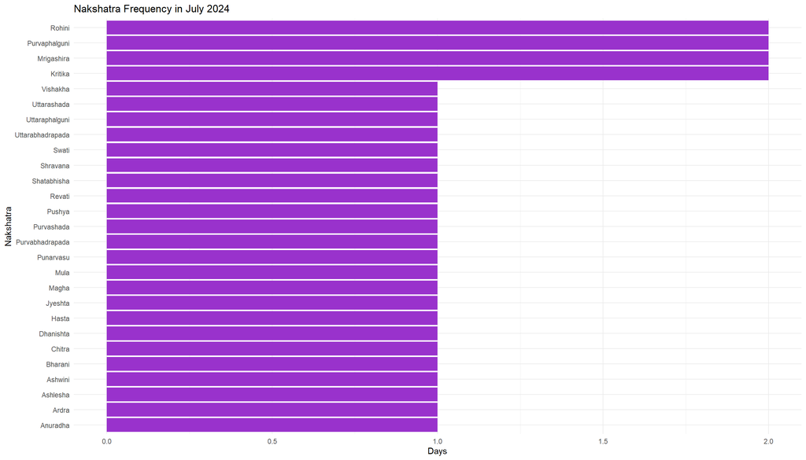

```r
nak_names <- sapply(jd, function(x) get_nakshatra_name(x, place)$nakshatra[1])
nak_df <- data.frame(nakshatra = nak_names) %>% count(nakshatra)

ggplot(nak_df, aes(x = reorder(nakshatra, n), y = n)) +
  geom_col(fill = "darkorchid") +
  coord_flip() +
  theme_minimal() +
  labs(
    title = "Nakshatra Frequency in July 2024",
    x = "Nakshatra",
    y = "Days"
  )
```

**Interpretation:** Observe which Nakshatras dominate the month, and their frequency—a direct window into the lunar sky divisions.

## 4. Tithi and Nakshatra Strips with Enhanced Color

**Purpose:** To compare the progression of Tithis and Nakshatras, with each color uniquely identifying the calendar entity.

### Tithi Strip

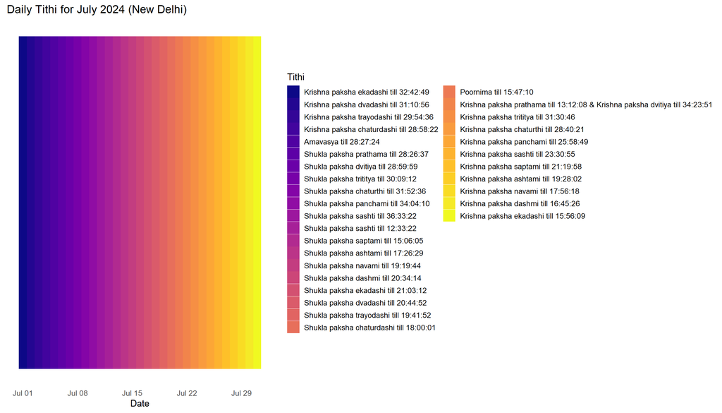

```r
ggplot(panchanga, aes(x = date, y = 1, fill = fct_inorder(tithi))) +
  geom_tile(height = 0.8) +
  scale_fill_viridis_d(option = "plasma", guide = guide_legend(nrow = 20)) +
  labs(title = "Daily Tithi for July 2024 (New Delhi)", fill = "Tithi", y = NULL, x = "Date") +
  theme_minimal(base_size = 13) +
  theme(axis.text.y = element_blank(),
        axis.ticks.y = element_blank(),
        panel.grid = element_blank())
```

### Nakshatra Strip

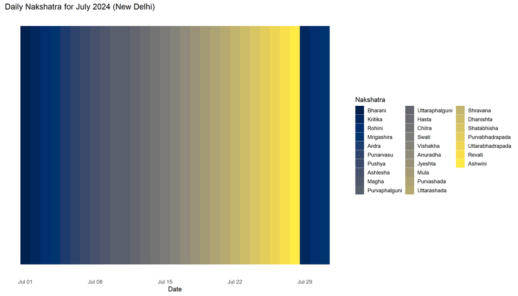

```r
ggplot(panchanga, aes(x = date, y = 1, fill = fct_inorder(nakshatra))) +
  geom_tile(height = 0.8) +
  scale_fill_viridis_d(option = "cividis", guide = guide_legend(nrow = 10)) +
  labs(title = "Daily Nakshatra for July 2024 (New Delhi)", fill = "Nakshatra", y = NULL, x = "Date") +
  theme_minimal(base_size = 13) +
  theme(axis.text.y = element_blank(),
        axis.ticks.y = element_blank(),
        panel.grid = element_blank())
```

## 5. Nakshatra Frequency (Horizontal Barplot)

**Purpose:** An alternate, more compact barplot to show which Nakshatras dominate the month.

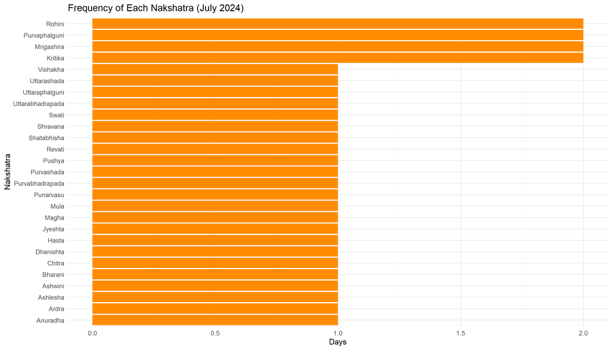

```r
panchanga %>%
  count(nakshatra) %>%
  ggplot(aes(x = fct_reorder(nakshatra, n), y = n)) +
  geom_col(fill = "darkorange") +
  coord_flip() +
  labs(title = "Frequency of Each Nakshatra (July 2024)", x = "Nakshatra", y = "Days") +
  theme_minimal(base_size = 13)
```

## 6. Day Length in July (Line Plot)

**Purpose:** To see how much day length varies even within a single month at a given location.

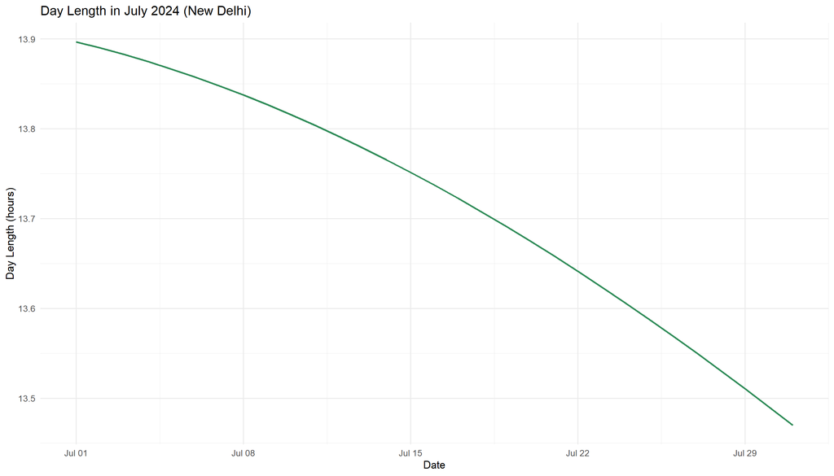

```r
panchanga$day_length <- sapply(panchanga$jd, function(x) day_duration(x, place)$duration_hours)

ggplot(panchanga, aes(x = date, y = day_length)) +
  geom_line(color = "seagreen", size = 1) +
  labs(title = "Day Length in July 2024 (New Delhi)", x = "Date", y = "Day Length (hours)") +
  theme_minimal(base_size = 13)
```

## 7. Lunar Rashi Block Plot

**Purpose:** Shows the lunar zodiac sign (Rashi) for each day, visualizing how the moon traverses the zodiac over the month.

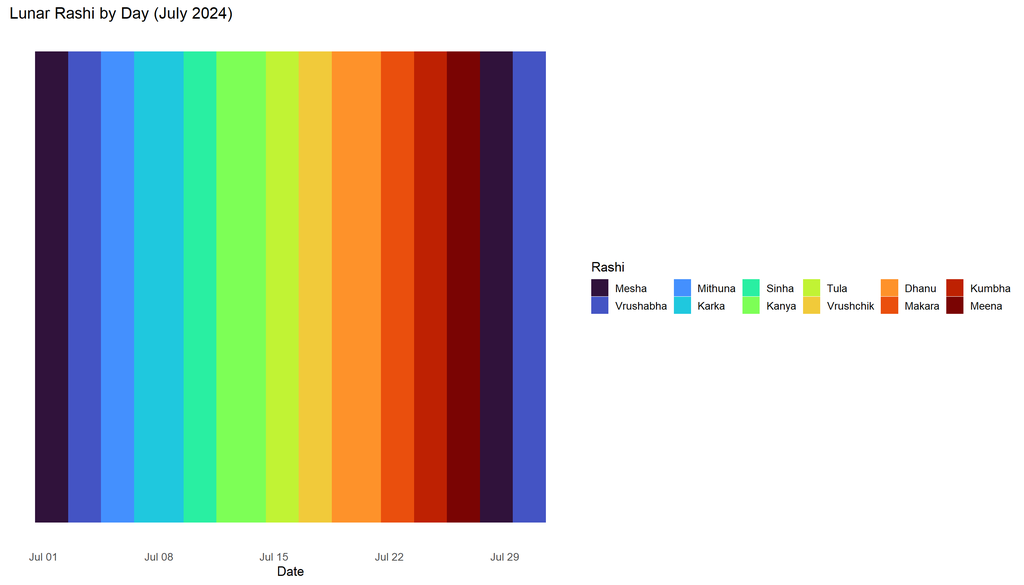

```r
ggplot(panchanga, aes(x = date, y = 1, fill = fct_inorder(rashi))) +
  geom_tile(height = 0.8) +
  scale_fill_viridis_d(option = "turbo", guide = guide_legend(nrow = 2)) +
  labs(title = "Lunar Rashi by Day (July 2024)", fill = "Rashi", y = NULL, x = "Date") +
  theme_minimal(base_size = 13) +
  theme(axis.text.y = element_blank(),
        axis.ticks.y = element_blank(),
        panel.grid = element_blank())
```

## 8. Highlighting Special Tithis: Amavasya and Poornima

**Purpose:** To visually pick out the new moon (Amavasya) and full moon (Poornima) days in the Tithi strip. Special days are marked with red points.

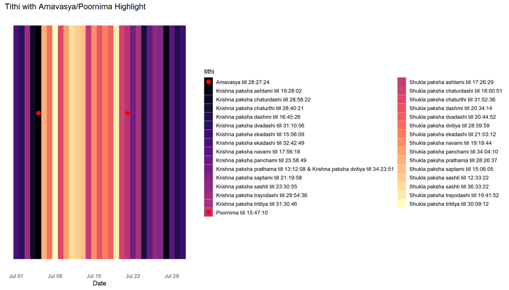

```r
panchanga$is_special <- grepl("Amavasya|Poornima", panchanga$tithi)

ggplot(panchanga, aes(x = date, y = 1, fill = tithi)) +
  geom_tile(height = 0.8) +
  geom_point(data = subset(panchanga, is_special), aes(x = date, y = 1.1), color = "red", size = 4) +
  scale_fill_viridis_d(option = "magma") +
  labs(title = "Tithi with Amavasya/Poornima Highlight", y = NULL, x = "Date") +
  theme_minimal(base_size = 13) +
  theme(axis.text.y = element_blank(),
        axis.ticks.y = element_blank(),
        panel.grid = element_blank())
```

## 9. Panchanga Elements with Direct Labels

**Purpose:** Removes the legend entirely and labels each tile with the actual Panchanga value (vertical text), providing an at-a-glance calendar strip.

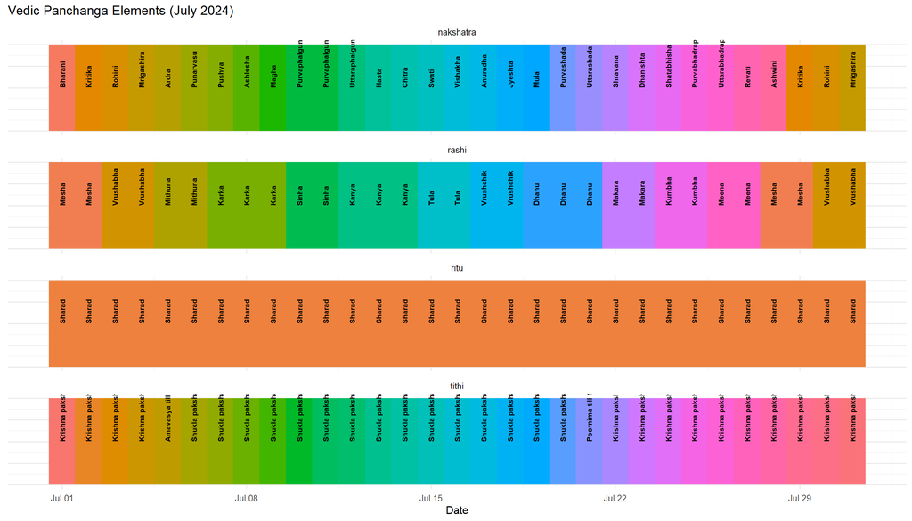

```r
long_pan <- panchanga %>%
  pivot_longer(cols = c(tithi, nakshatra, rashi, ritu), names_to = "element", values_to = "value")

ggplot(long_pan, aes(x = date, y = 1, fill = fct_inorder(value))) +
  geom_tile(height = 0.8) +
  geom_text(
    aes(label = value),
    angle = 90,
    vjust = 0.5, hjust = 0,
    size = 2.8,
    color = "black",
    fontface = "bold"
  ) +
  facet_wrap(~element, ncol = 1, scales = "free_y") +
  labs(
    title = "Vedic Panchanga Elements (July 2024)",
    y = NULL, x = "Date"
  ) +
  theme_minimal(base_size = 12) +
  theme(
    axis.text.y = element_blank(),
    axis.ticks.y = element_blank(),
    legend.position = "none"
  )
```

# Conclusion

These visualizations not only **illustrate the astronomical and calendrical depth of the Indian Panchanga**, but also demonstrate how the VedicDateTime package, when paired with tidyverse and ggplot2, enables modern, reproducible, and visually rich calendar analysis.

*For questions, contributions, or more visualization ideas, see the package documentation and vignettes!*

```
---
```